# Analisys of most harmful weather events in USA according to data of NOAA Storm Database

Igor Goltsov

June 20, 2015

## Synopsis

The analisys of the Storm Database provided by [NOAA](http://www.ncdc.noaa.gov/stormevents/) shown, that tornados are most harmful with respect to population health. In the other hand, the most valuable economical consequencies are provided by floods.

## Data Processing

The data for anaylis is provided by [NOAA](http://www.ncdc.noaa.gov/stormevents/). The data about any storm events may be found there. Will use the [package](https://d396qusza40orc.cloudfront.net/repdata%2Fdata%2FStormData.csv.bz2) that provided by Coursera [Reproducible Research](https://class.coursera.org/repdata-015) course.

### Download package

Check if *repdata_Fdata_FStormData.csv.bz2* file exists in *data* folder and download the package from link shown below if it didn’t.

```r
package.name <- "data/repdata_Fdata_FStormData.csv.bz2"
package.url <- "https://d396qusza40orc.cloudfront.net/repdata%2Fdata%2FStormData.csv.bz2"

if (!file.exists(package.name)){
    download.file(package.url, package.name, method="curl")
}
```

Can load data into the variable *storm.data* and prepare it for further analisys.

```r
storm.data <- read.csv(bzfile(package.name))
dim(storm.data)
```

```
## [1] 902297     37
```

```r
head(storm.data)
```

```
##   STATE__           BGN_DATE BGN_TIME TIME_ZONE COUNTY COUNTYNAME STATE
## 1       1  4/18/1950 0:00:00     0130       CST     97     MOBILE    AL
## 2       1  4/18/1950 0:00:00     0145       CST      3    BALDWIN    AL
## 3       1  2/20/1951 0:00:00     1600       CST     57    FAYETTE    AL
## 4       1   6/8/1951 0:00:00     0900       CST     89    MADISON    AL
## 5       1 11/15/1951 0:00:00     1500       CST     43    CULLMAN    AL
## 6       1 11/15/1951 0:00:00     2000       CST     77 LAUDERDALE    AL
##    EVTYPE BGN_RANGE BGN_AZI BGN_LOCATI END_DATE END_TIME COUNTY_END
## 1 TORNADO         0                                               0
## 2 TORNADO         0                                               0
## 3 TORNADO         0                                               0
## 4 TORNADO         0                                               0
## 5 TORNADO         0                                               0
## 6 TORNADO         0                                               0
##   COUNTYENDN END_RANGE END_AZI END_LOCATI LENGTH WIDTH F MAG FATALITIES
```

[output cut: 20 more lines]

### Data Processing

Property and Crop Damage values should be arranged into one unit of measure

Function **arrange_unit_of_measure(value, exp)** will arrange value of damage for property and crop.

```r
arrange_unit_of_measure <- function(value, exp){
    value <- as.numeric(value)

    if (exp %in% c("k","K")){
        exp <- 3
    }

    if (exp %in% c("m","M")){
        exp <- 6
    }

    if (exp %in% c("b","B")){
        exp <- 9
    }

    if (is.numeric(value) && is.numeric(exp)){
        value*10^exp
    } else {
        0
    }
}
```

Use **apply()** to arrange units of measure for property damages.

```r
arranged.prop.damage <- as.numeric(
  apply(storm.data, 1, function(x) {
    prop.dmg <- as.numeric(x[25])
    prop.dmg.exp <- x[26]

    arrange_unit_of_measure(prop.dmg, prop.dmg.exp)
  })
)
summary(arranged.prop.damage)
```

```
##      Min.   1st Qu.    Median      Mean   3rd Qu.      Max.
## 0.000e+00 0.000e+00 0.000e+00 4.736e+05 5.000e+02 1.150e+11
```

```r
arranged.crop.damage <- as.numeric(
  apply(storm.data, 1, function(x) {
    crop.dmg <- as.numeric(x[27])
    crop.dmg.exp <- x[28]

    arrange_unit_of_measure(crop.dmg, crop.dmg.exp)
  })
)
summary(arranged.crop.damage)
```

```
##      Min.   1st Qu.    Median      Mean   3rd Qu.      Max.
## 0.000e+00 0.000e+00 0.000e+00 5.442e+04 0.000e+00 5.000e+09
```

Squeeze the data required for the analisys only.

```r
library(dplyr)
analisys.data <- select(
    storm.data,
    EVTYPE,
    FATALITIES,
    INJURIES
)

analisys.data$PROPERTY.DAMAGE <- arranged.prop.damage
analisys.data$CROP.DAMAGE <- arranged.crop.damage

names(analisys.data) <- c(
    "event_type",
    "fatalities",
    "injuries",
    "property_damage",
    "crop_damage"
)

str(analisys.data)
```

```
## 'data.frame':    902297 obs. of  5 variables:
##  $ event_type     : Factor w/ 985 levels "?","ABNORMALLY DRY",..: 830 830 830 830 830 830 830 830 830 830 ...
##  $ fatalities     : num  0 0 0 0 0 0 0 0 1 0 ...
##  $ injuries       : num  15 0 2 2 2 6 1 0 14 0 ...
##  $ property_damage: num  25000 2500 25000 2500 2500 2500 2500 2500 25000 25000 ...
##  $ crop_damage    : num  0 0 0 0 0 0 0 0 0 0 ...
```

Now the data is clean and ready for analisys.

## Results

The most harmfull for population weather events could be identified by quantity of Injuries and Fatalities presented in the *analisys.data* variable.

### Events most harmful with respect to population

The most harmful types of event are 20% of events with greatest population harm values.

```r
library(dplyr)
population_harm <- select(analisys.data, event_type, fatalities, injuries) %>%
                    group_by(event_type) %>%
                    summarise(harm = sum(fatalities + injuries))

quantiles <- quantile(
    population_harm[population_harm$harm > 0, ]$harm,
    probs = seq(0 , 1, 0.20)
)

print(quantiles)
```

```
##    0%   20%   40%   60%   80%  100%
##     1     1     3    14    92 96979
```

```r
limit_harm <- quantiles[[5]]

print(limit_harm)
```

```
## [1] 92
```

It looks like all types of event with popiulation harm greatest then 92 people are most harmful. Build the top of most harmful to population events. The events what qualified as most harmful are called by name and all other events are called as “OTHER EVENTS”.

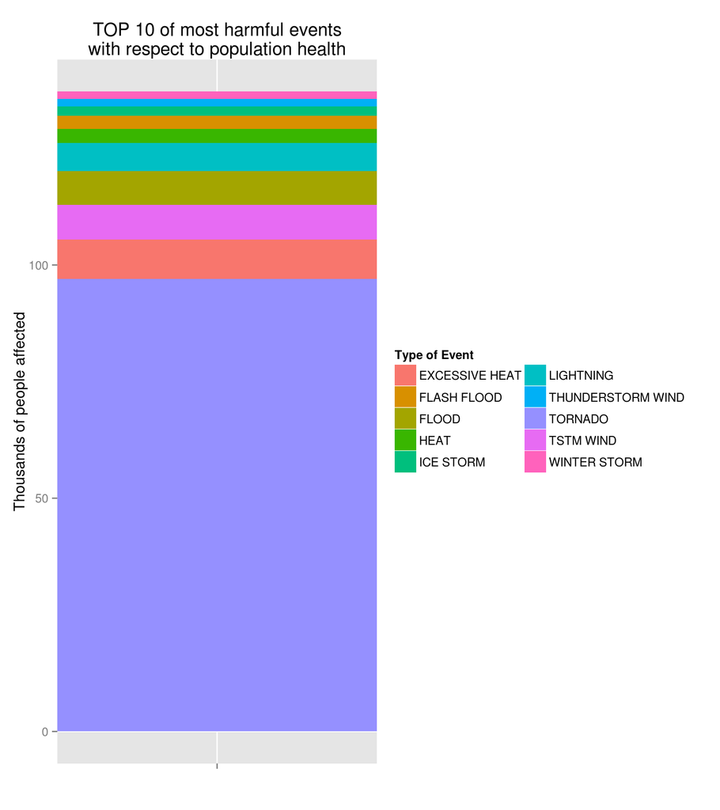

```r
most_harmful_events <- select(population_harm, event_type, harm) %>%
                    filter(harm >= limit_harm) %>%
                    arrange(desc(harm))

less_harmful_events <- select(population_harm, event_type, harm) %>%
                    filter(harm < limit_harm)

summary_of_harm <- rbind(
    most_harmful_events,
    data.frame(
        event_type = "OTHER EVENTS",
        harm = sum(less_harmful_events$harm)
    )
)

# Print plot what illustrates most harmful events

library(ggplot2)
ggplot(
        summary_of_harm[1:10, ],
        aes(x="", fill=event_type, y=harm / 10^3)
    ) +
    geom_bar(width=1, stat = "identity") +
    guides(fill=guide_legend(
        ncol=2,
        title = "Type of Event"
    )) +
    ggtitle("TOP 10 of most harmful events\nwith respect to population health") +
    xlab("") +
    ylab("Thousands of people affected")
```

#### Complete list of weather events that most harmful to population

```r
library(knitr)
names(summary_of_harm) <- c("Event Type", "People harmed")
kable(summary_of_harm, digits=2)
```

| Event Type | People harmed |
| --- | --- |
| TORNADO | 96979 |
| EXCESSIVE HEAT | 8428 |
| TSTM WIND | 7461 |
| FLOOD | 7259 |
| LIGHTNING | 6046 |
| HEAT | 3037 |
| FLASH FLOOD | 2755 |
| ICE STORM | 2064 |
| THUNDERSTORM WIND | 1621 |
| WINTER STORM | 1527 |
| HIGH WIND | 1385 |
| HAIL | 1376 |
| HURRICANE/TYPHOON | 1339 |
| HEAVY SNOW | 1148 |
| WILDFIRE | 986 |
| THUNDERSTORM WINDS | 972 |
| BLIZZARD | 906 |
| FOG | 796 |
| RIP CURRENT | 600 |
| WILD/FOREST FIRE | 557 |
| RIP CURRENTS | 501 |
| HEAT WAVE | 481 |
| DUST STORM | 462 |
| WINTER WEATHER | 431 |
| TROPICAL STORM | 398 |
| AVALANCHE | 394 |
| EXTREME COLD | 391 |
| STRONG WIND | 383 |
| DENSE FOG | 360 |
| HEAVY RAIN | 349 |
| HIGH WINDS | 337 |
| HIGH SURF | 253 |
| EXTREME HEAT | 251 |
| GLAZE | 223 |
| TSUNAMI | 162 |
| WILD FIRES | 153 |
| EXTREME COLD/WIND CHILL | 149 |
| ICE | 143 |
| WIND | 109 |
| COLD/WIND CHILL | 107 |
| HURRICANE | 107 |
| URBAN/SML STREAM FLD | 107 |
| TSTM WIND/HAIL | 100 |
| WINTER WEATHER/MIX | 100 |
| OTHER EVENTS | 1980 |

### Events that has the greatest economic consequences

Events that has the greatest economical consequences are 20% of events with greatest economical damage values.

```r
library(dplyr)
economical_damage <- select(analisys.data, event_type, property_damage, crop_damage) %>%
                    group_by(event_type) %>%
                    summarise(damage = sum( (property_damage + crop_damage) / 10^6 ))

quantiles <- quantile(
    economical_damage[economical_damage$damage > 0, ]$damage,
    probs = seq(0 , 1, 0.20)
)

print(quantiles)
```

```
##           0%          20%          40%          60%          80%
##      0.00005      0.01000      0.06000      0.65500     13.10000
##         100%
## 150319.67825
```

```r
limit_damage <- quantiles[[5]]

print(limit_damage)
```

```
## [1] 13.1
```

It looks like all types of event with damage greatest then 13.1 millions of dollars are most harmful to economics. Build the top of events with greatest economic consequencies. The events what qualified as most damagable are called by name and all other events are called as “OTHER EVENTS”.

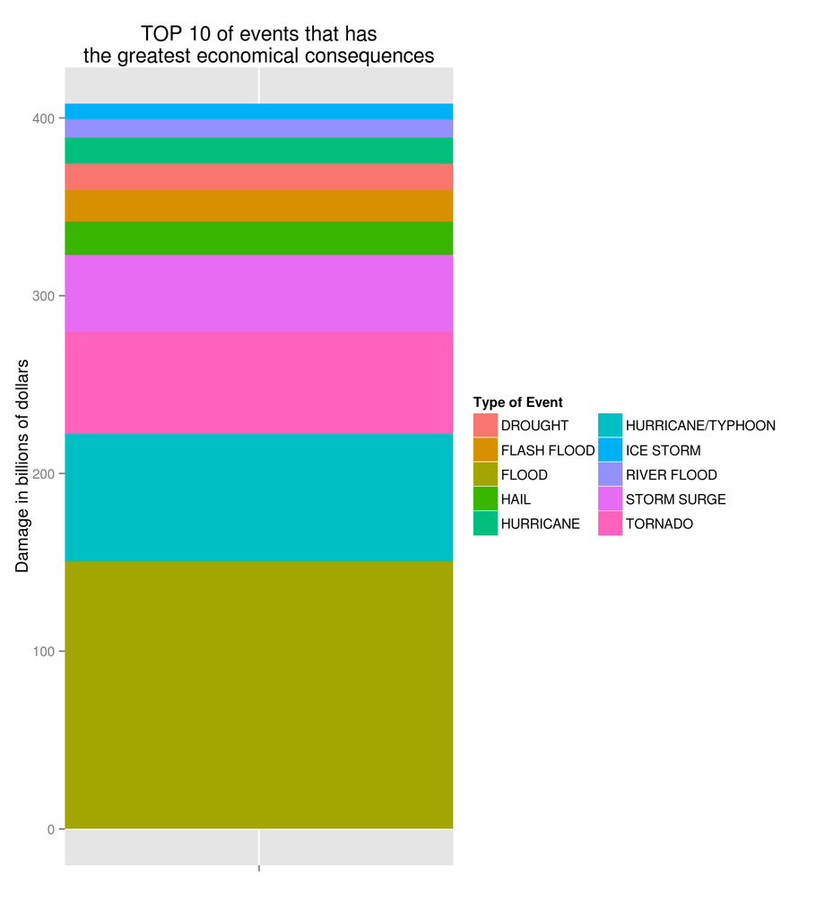

```r
most_damagable_events <- select(economical_damage, event_type, damage) %>%
                    filter(damage >= limit_damage) %>%
                    mutate(damage = damage / 10^3) %>%
                    arrange(desc(damage))

less_damagable_events <- select(economical_damage, event_type, damage) %>%
                    filter(damage < limit_damage) %>%
                    mutate(damage = damage / 10^3)


summary_of_economical_damage <- rbind(
    most_damagable_events,
    data.frame(
        event_type = "OTHER EVENTS",
        damage = sum(less_damagable_events$damage)
    )
)

library(ggplot2)
ggplot(
        summary_of_economical_damage[1:10, ],
        aes(x="", fill=event_type, y=damage)
    ) +
    geom_bar(width=1, stat = "identity") +
    guides(fill=guide_legend(
        ncol=2,
        title = "Type of Event"
    )) +
    ggtitle("TOP 10 of events that has\nthe greatest economical consequences") +
    xlab("") +
    ylab("Damage in billions of dollars")
```

#### Complete list of weather events with greatest economical damage

```r
library(knitr)
names(summary_of_economical_damage) <- c("Event Type", "Damage in billions of dollars")
kable(summary_of_economical_damage, digits=2)
```

| Event Type | Damage in billions of dollars |
| --- | --- |
| FLOOD | 150.32 |
| HURRICANE/TYPHOON | 71.91 |
| TORNADO | 57.35 |
| STORM SURGE | 43.32 |
| HAIL | 18.76 |
| FLASH FLOOD | 17.56 |
| DROUGHT | 15.02 |
| HURRICANE | 14.61 |
| RIVER FLOOD | 10.15 |
| ICE STORM | 8.97 |
| TROPICAL STORM | 8.38 |
| WINTER STORM | 6.72 |
| HIGH WIND | 5.91 |
| WILDFIRE | 5.06 |
| TSTM WIND | 5.04 |
| STORM SURGE/TIDE | 4.64 |
| THUNDERSTORM WIND | 3.90 |
| HURRICANE OPAL | 3.19 |
| WILD/FOREST FIRE | 3.11 |
| HEAVY RAIN/SEVERE WEATHER | 2.50 |
| THUNDERSTORM WINDS | 1.93 |
| TORNADOES, TSTM WIND, HAIL | 1.60 |
| HEAVY RAIN | 1.43 |
| EXTREME COLD | 1.36 |
| SEVERE THUNDERSTORM | 1.21 |
| FROST/FREEZE | 1.10 |
| HEAVY SNOW | 1.07 |
| LIGHTNING | 0.94 |
| BLIZZARD | 0.77 |
| HIGH WINDS | 0.65 |

[output cut: 57 more lines]